# Covid Analysis

Untitled

2023-06-02

Introduction:

In this analysis, we are trying to understand the number of covid cases, deaths and recovery from the John Hopkins data available in github.

We will also try to establish a relationship between deaths and other independent variables. There are 6 data sources.

1. Cases in United States
2. Deaths in United States
3. Global Cases
4. Global Deaths
5. Global Recovery
6. Population by Province and Country

```r
# Import the required packages
library(tidyverse)
library(dplyr)
library(tidyr)
library(car)
url = "https://raw.githubusercontent.com/CSSEGISandData/COVID-19/master/csse_covid_19_data/csse_covid_19_time_series/"

filenames = c("time_series_covid19_confirmed_US.csv","time_series_covid19_confirmed_global.csv","time_series_covid19_deaths_US.csv","time_series_covid19_deaths_global.csv","time_series_covid19_recovered_global.csv")

urls =str_c(url,filenames)
urls
```

```
## [1] "https://raw.githubusercontent.com/CSSEGISandData/COVID-19/master/csse_covid_19_data/csse_covid_19_time_series/time_series_covid19_confirmed_US.csv"
## [2] "https://raw.githubusercontent.com/CSSEGISandData/COVID-19/master/csse_covid_19_data/csse_covid_19_time_series/time_series_covid19_confirmed_global.csv"
## [3] "https://raw.githubusercontent.com/CSSEGISandData/COVID-19/master/csse_covid_19_data/csse_covid_19_time_series/time_series_covid19_deaths_US.csv"
## [4] "https://raw.githubusercontent.com/CSSEGISandData/COVID-19/master/csse_covid_19_data/csse_covid_19_time_series/time_series_covid19_deaths_global.csv"
## [5] "https://raw.githubusercontent.com/CSSEGISandData/COVID-19/master/csse_covid_19_data/csse_covid_19_time_series/time_series_covid19_recovered_global.csv"
```

```r
us_cases = read_csv(urls[1])
global_cases = read_csv(urls[3])
us_deaths = read_csv(urls[3])
global_deaths = read_csv(urls[4])
global_recovered = read_csv(urls[5])
population=read_csv("https://raw.githubusercontent.com/CSSEGISandData/COVID-19/master/csse_covid_19_data/UID_ISO_FIPS_LookUp_Table.csv")
# Analyzing Global Recovered Data

global_recovered <- global_recovered %>% pivot_longer(cols=-c(`Province/State`,`Country/Region`,Lat, Long),
                                                      names_to = "date",
                                                      values_to = "recovered")%>%
  select(-c(Lat,Long))

global_cases <- select(global_cases,-c(Lat,Long_,UID,iso2,iso3,code3,FIPS,Admin2))

global_cases <- global_cases %>%
  select(-c(Combined_Key, Population)) %>%
  pivot_longer(cols = -c(Province_State, Country_Region),
               names_to = "date",
               values_to = "cases")


global_deaths <- global_deaths %>% pivot_longer(cols=-c(`Province/State`,`Country/Region`,Lat, Long),
                                                      names_to = "date",
                                                      values_to = "deaths")%>%
  select(-c(Lat,Long))

global_cases$date <- as.Date(global_cases$date,format="%m/%d/%y")
global_recovered$date <- as.Date(global_recovered$date,format="%m/%d/%y")
global_deaths$date <- as.Date(global_deaths$date,format="%m/%d/%y")

# only selected countries

selected_countries <- c("China", "United Kingdom", "India")

global_recovered_filtered <- subset(global_recovered, `Country/Region` %in% selected_countries)

global_deaths_filtered<- subset(global_deaths, `Country/Region` %in% selected_countries)

global_cases_filtered<- subset(global_cases, Country_Region %in% selected_countries)

global <- global_recovered_filtered %>% full_join(global_deaths_filtered)
colnames(global)[colnames(global) == "Country/Region"] <- "Country_Region"

population_countries = subset(population, select = c(Country_Region, Combined_Key,Population))

population_filtered <- subset(population_countries, Country_Region %in% selected_countries)

global<- unite(global, Combined_Key, 'Province/State', 'Country_Region', sep = ", ")

global <- merge(global, population_filtered, by = "Combined_Key")

global <- separate(global, Combined_Key, into = c("Province/State", "Country"), sep = ", ")
global_by_state <- global %>% group_by(`Province/State`,Country_Region,date)%>%
  summarize(recovered=sum(recovered),deaths=sum(deaths),Population=sum(Population))%>%
  mutate(deaths_per_mil=deaths*1000000/Population)%>%
  select('Province/State',Country_Region,date,deaths,recovered,deaths_per_mil,Population)%>%
  ungroup()
```

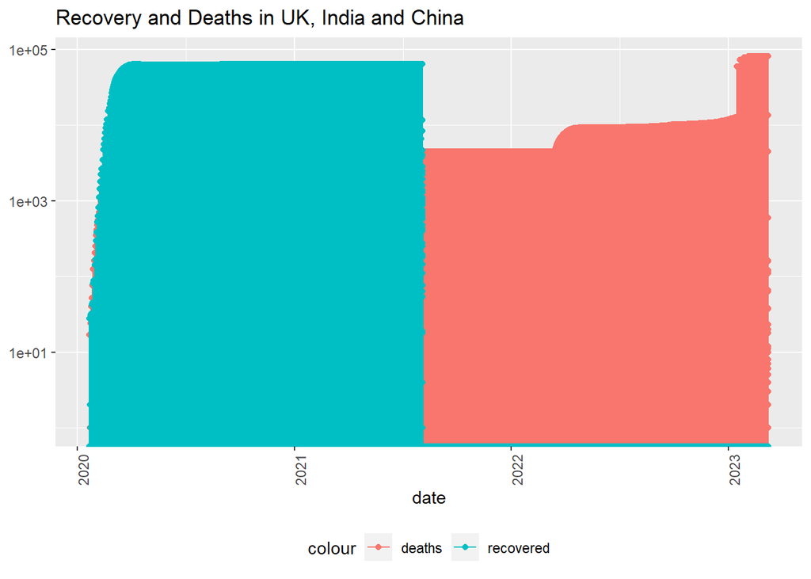

```r
global_by_state %>%
  ggplot(aes(x=date,y=deaths))+
  geom_line(aes(color="deaths"))+
  geom_point(aes(color="deaths"))+
  geom_line(aes(y=recovered,color="recovered"))+
  geom_point(aes(y=recovered,color="recovered"))+
  scale_y_log10()+
  theme(legend.position="bottom",
        axis.text.x=element_text(angle=90))+
  labs(title = "Recovery and Deaths in UK, India and China",y=NULL)
```

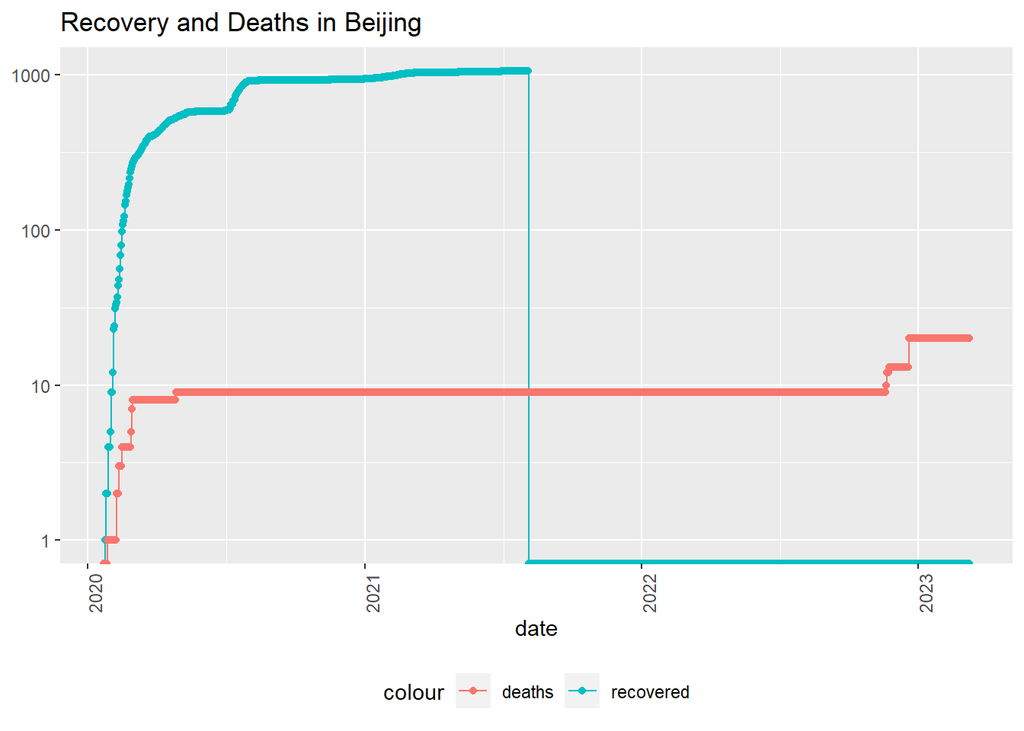

```r
province="Beijing"

global_by_state %>%
  filter(`Province/State`==province)%>%
  ggplot(aes(x=date,y=recovered))+
  geom_line(aes(color="recovered"))+
  geom_point(aes(color="recovered"))+
  geom_line(aes(y=deaths,color="deaths"))+
  geom_point(aes(y=deaths,color="deaths"))+
  scale_y_log10()+
  theme(legend.position="bottom",
        axis.text.x=element_text(angle=90))+
  labs(title = str_c("Recovery and Deaths in ",province),y=NULL)
```

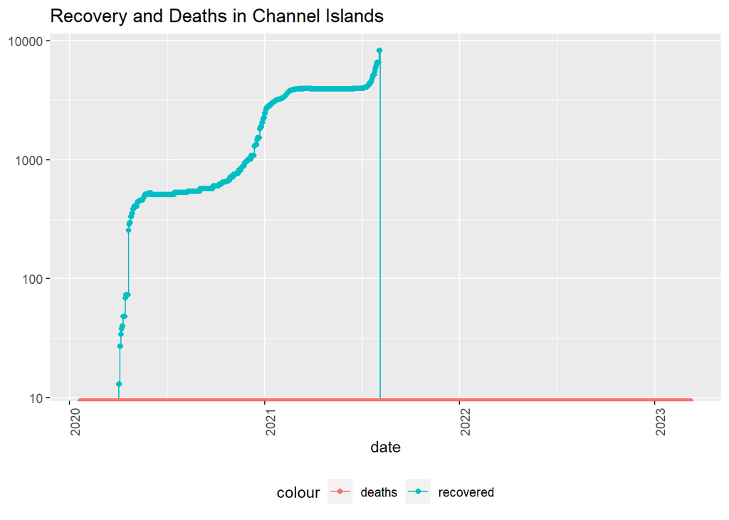

```r
province="Channel Islands"

global_by_state %>%
  filter(`Province/State`==province)%>%
  ggplot(aes(x=date,y=recovered))+
  geom_line(aes(color="recovered"))+
  geom_point(aes(color="recovered"))+
  geom_line(aes(y=deaths,color="deaths"))+
  geom_point(aes(y=deaths,color="deaths"))+
  scale_y_log10()+
  theme(legend.position="bottom",
        axis.text.x=element_text(angle=90))+
  labs(title = str_c("Recovery and Deaths in ",province),y=NULL)
```

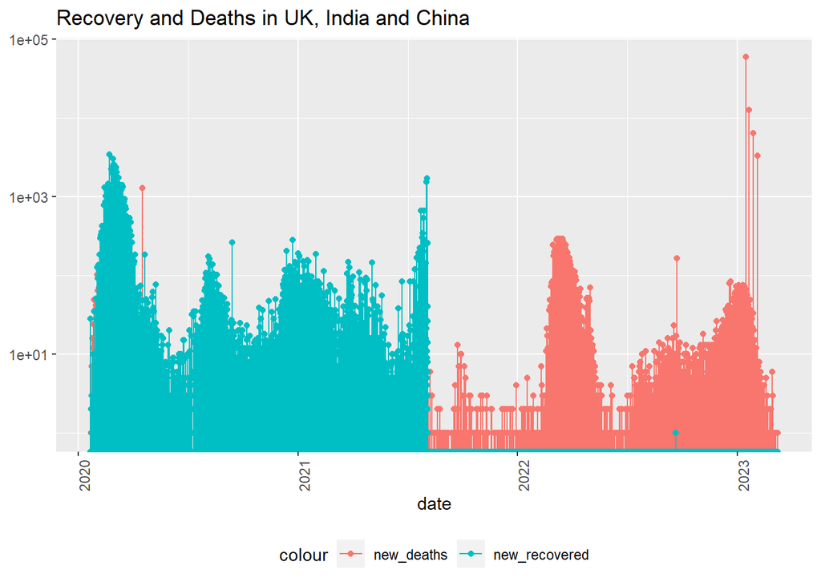

```r
global_by_state <- global_by_state %>% mutate(new_recovered = recovered-lag(recovered),
                                              new_deaths = deaths-lag(deaths))

global_by_state %>%
  ggplot(aes(x=date,y=new_deaths))+
  geom_line(aes(color="new_deaths"))+
  geom_point(aes(color="new_deaths"))+
  geom_line(aes(y=new_recovered,color="new_recovered"))+
  geom_point(aes(y=new_recovered,color="new_recovered"))+
  scale_y_log10()+
  theme(legend.position="bottom",
        axis.text.x=element_text(angle=90))+
  labs(title = "Recovery and Deaths in UK, India and China",y=NULL)
```

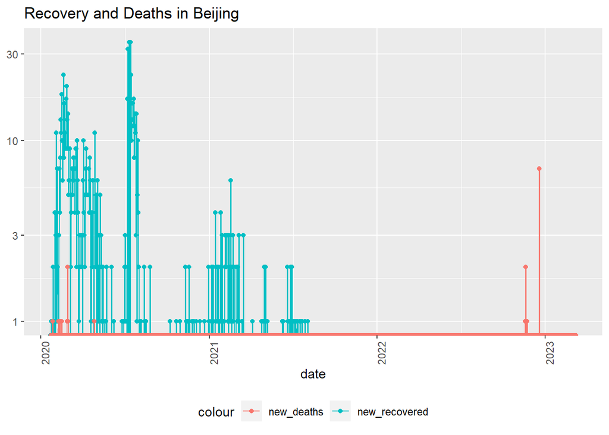

```r
province="Beijing"

global_by_state %>%
  filter(`Province/State`==province)%>%
  ggplot(aes(x=date,y=new_recovered))+
  geom_line(aes(color="new_recovered"))+
  geom_point(aes(color="new_recovered"))+
  geom_line(aes(y=new_deaths,color="new_deaths"))+
  geom_point(aes(y=new_deaths,color="new_deaths"))+
  scale_y_log10()+
  theme(legend.position="bottom",
        axis.text.x=element_text(angle=90))+
  labs(title = str_c("Recovery and Deaths in ",province),y=NULL)
```